# Regresión con variable politómica (3 grupos)

dacarras

# Ejemplo 1

- Primera encuesta de polivictimizacion (2017)
- 19.684 observaciones estudiantes, de 699 escuelas
- Ponderación de la muestra se realiza mediante ajustes de post-estratificación por sexo, edad, dependencia administrativa del establecimiento y región

## Variables

- Variable de respuesta
  - Depresion: escala de depresión infantil de Birleson
- Factor Sociodemográficos
  - Sexo
  - Edad
- Factores Escolares
  - Depedencia Administrativa
- Factores de Riesgo
  - Polivictimas de vida (10% de la población con mayor exposicion a eventos de violencia)
  - Polivictimas al año (10% de la población con mayor exposicion a eventos de violencia)

## Abrir datos

```r
#----------------------------------------------------------
# abrir datos
#----------------------------------------------------------

# -----------------------------------------------
# abrir datos desde github
# -----------------------------------------------


data_poly <- readRDS(
url('https://github.com/dacarras/psi4035_examples/raw/master/data/data_poly_all.rds')
)

# -----------------------------------------------
# inspeccionar datos
# -----------------------------------------------

library(dplyr)
data_poly %>%
labelled::look_for() %>%
labelled::lookfor_to_long_format() %>%
tibble::as_tibble() %>%
knitr::kable()
```

| pos | variable | label | col_type | levels | value_labels |
| --- | --- | --- | --- | --- | --- |
| 1 | m16_rbd | Código RBD del establecimiento en 2016 | dbl |  |  |
| 2 | m17_rbd | Código RBD del establecimiento en 2017 | dbl |  |  |
| 3 | fuente | Nombre de la planilla de captura digital de donde viene el dato | chr |  |  |
| 4 | folio | Folio UC | dbl |  |  |
| 5 | P1_1 | ¿En qué curso estás actualmente? | dbl+lbl |  | [1] Séptimo Básico |
| 5 | P1_1 | ¿En qué curso estás actualmente? | dbl+lbl |  | [2] Octavo Básico |
| 5 | P1_1 | ¿En qué curso estás actualmente? | dbl+lbl |  | [3] Primero Medio |
| 5 | P1_1 | ¿En qué curso estás actualmente? | dbl+lbl |  | [4] Segundo Medio |
| 5 | P1_1 | ¿En qué curso estás actualmente? | dbl+lbl |  | [5] Tercero Medio |
| 6 | P1_2 | ¿Cuál es tu sexo? | dbl+lbl |  | [1] Mujer |
| 6 | P1_2 | ¿Cuál es tu sexo? | dbl+lbl |  | [2] Hombre |
| 7 | P1_3 | ¿Cuál es tu edad? | dbl+lbl |  | [1] 12 años |
| 7 | P1_3 | ¿Cuál es tu edad? | dbl+lbl |  | [2] 13 años |
| 7 | P1_3 | ¿Cuál es tu edad? | dbl+lbl |  | [3] 14 años |
| 7 | P1_3 | ¿Cuál es tu edad? | dbl+lbl |  | [4] 15 años |
| 7 | P1_3 | ¿Cuál es tu edad? | dbl+lbl |  | [5] 16 años |
| 7 | P1_3 | ¿Cuál es tu edad? | dbl+lbl |  | [6] 17 años |
| 7 | P1_3 | ¿Cuál es tu edad? | dbl+lbl |  | [7] 18 años |
| 7 | P1_3 | ¿Cuál es tu edad? | dbl+lbl |  | [8] 19 años o más |
| 8 | P1_4 | ¿En qué país naciste tú? | dbl+lbl |  | [1] Chile |
| 8 | P1_4 | ¿En qué país naciste tú? | dbl+lbl |  | [2] Argentina |
| 8 | P1_4 | ¿En qué país naciste tú? | dbl+lbl |  | [3] Perú |
| 8 | P1_4 | ¿En qué país naciste tú? | dbl+lbl |  | [4] Bolivia |
| 8 | P1_4 | ¿En qué país naciste tú? | dbl+lbl |  | [5] Uruguay |
| 8 | P1_4 | ¿En qué país naciste tú? | dbl+lbl |  | [6] Brasil |
| 8 | P1_4 | ¿En qué país naciste tú? | dbl+lbl |  | [7] Colombia |
| 8 | P1_4 | ¿En qué país naciste tú? | dbl+lbl |  | [8] Haití |
| 8 | P1_4 | ¿En qué país naciste tú? | dbl+lbl |  | [9] República Dominicana |
| 8 | P1_4 | ¿En qué país naciste tú? | dbl+lbl |  | [10] Ecuador |
| 8 | P1_4 | ¿En qué país naciste tú? | dbl+lbl |  | [11] Venezuela |

[output cut: 993 more lines]

```r
# -----------------------------------------------
# inspeccionar datos (variables)
# -----------------------------------------------

library(dplyr)
data_poly %>%
labelled::look_for() %>%
labelled::lookfor_to_long_format() %>%
tibble::as_tibble() %>%
dplyr::select(variable, label) %>%
unique() %>%
knitr::kable()
```

| variable | label |
| --- | --- |
| m16_rbd | Código RBD del establecimiento en 2016 |
| m17_rbd | Código RBD del establecimiento en 2017 |
| fuente | Nombre de la planilla de captura digital de donde viene el dato |
| folio | Folio UC |
| P1_1 | ¿En qué curso estás actualmente? |
| P1_2 | ¿Cuál es tu sexo? |
| P1_3 | ¿Cuál es tu edad? |
| P1_4 | ¿En qué país naciste tú? |
| P1_5 | ¿En qué país nació tu madre? |
| P1_6 | ¿Perteneces o eres descendiente de alguno de los siguientes pueblos indígenas? |
| P1_7_1 | ¿Con quién vives? - Madre |
| P1_7_2 | ¿Con quién vives? - Padre |
| P1_7_3 | ¿Con quién vives? - Hermanas/os |
| P1_7_4 | ¿Con quién vives? - Hermanastras/os |
| P1_7_5 | ¿Con quién vives? - Abuela |
| P1_7_6 | ¿Con quién vives? - Abuelo |
| P1_7_7 | ¿Con quién vives? - Otros parientes |
| P1_7_8 | ¿Con quién vives? - Otros no parientes |
| P1_8_1 | ¿Tienes tú alguna de las siguientes condiciones permanentes y/o de larga duración? - Dificultad física y/o de movilidad |
| P1_8_2 | ¿Tienes tú alguna de las siguientes condiciones permanentes y/o de larga duración? - Mudez o dificultad en el habla |
| P1_8_3 | ¿Tienes tú alguna de las siguientes condiciones permanentes y/o de larga duración? - Dificultad mental o intelectual |
| P1_8_4 | ¿Tienes tú alguna de las siguientes condiciones permanentes y/o de larga duración? - Sordera o dificultad para oír aún usando audífonos |
| P1_8_5 | ¿Tienes tú alguna de las siguientes condiciones permanentes y/o de larga duración? - Ceguera o dificultad para ver aún usando lentes |
| P1_8_6 | ¿Tienes tú alguna de las siguientes condiciones permanentes y/o de larga duración? - No tengo ninguna condición de larga duración |
| PA_1 | Alguna vez en tu vida, ¿alguien te ha robado alguna cosa SIN USAR LA FUERZA? |
| PA_1_1 | Y durante los últimos 12 meses, ¿te ha pasado esto? |
| PA_1_2 | ¿Cuántas veces te ha pasado esto durante los últimos 12 meses? |
| PA_1_3 | Última vez - ¿Dónde ocurrió? |
| PA_1_4 | Última vez - La persona que lo hizo, ¿era un adulto, una adulta, un niño o una niña? |
| PA_2 | Alguna vez en tu vida, ¿alguien te ha robado alguna cosa UTILIZANDO LA FUERZA? |

[output cut: 289 more lines]

## Preparar datos

```r
#----------------------------------------------------------
# preparar datos
#----------------------------------------------------------

# -----------------------------------------------
# funcion para centrar
# -----------------------------------------------

c_mean <- function (x, j) {
    ave(x, j, FUN = function(x) mean(x, na.rm = T))
}

# -----------------------------------------------
# funcion para borrar meta data
# -----------------------------------------------

remove_labels <- function (x)  {
    data <- dplyr::mutate(x, across(everything(), as.vector))
    return(data)
}

# -----------------------------------------------
# datos para modelar
# -----------------------------------------------

data_model <- data_poly %>%
              # sexo
              mutate(sex = case_when(
                P1_2 == 1 ~ 1, # mujer
                P1_2 == 2 ~ 0  # hombre
                )) %>%
              # edad
              mutate(edad_text = case_when(
                edad_cat3 == 1 ~ '12 a 13',   # 12 a 13
                edad_cat3 == 2 ~ '14 a 15',   # 14 a 15
                edad_cat3 == 3 ~ '16 o más'   # 16 o mas
                )) %>%
              mutate(ed1 = case_when(
                edad_cat3 == 1 ~ 1,  # 12 a 13
                edad_cat3 == 2 ~ 0,  # 14 a 15
                edad_cat3 == 3 ~ 0   # 16 o mas
                )) %>%
              mutate(ed2 = case_when(
                edad_cat3 == 1 ~ 0,  # 12 a 13
                edad_cat3 == 2 ~ 1,  # 14 a 15
                edad_cat3 == 3 ~ 0   # 16 o mas
                )) %>%
              mutate(ed3 = case_when(
                edad_cat3 == 1 ~ 0,  # 12 a 13
                edad_cat3 == 2 ~ 0,  # 14 a 15
                edad_cat3 == 3 ~ 1   # 16 o mas
                )) %>%
              # administración escolar
              mutate(adm_text = case_when(
                cod_depe_estudio == 1 ~ 'municipal',  # Municipal y AD
                cod_depe_estudio == 2 ~ 'subvencionado',  # Subvencionado
                cod_depe_estudio == 3 ~ 'particular'   # Particular
                )) %>%
              mutate(mun = case_when(
                cod_depe_estudio == 1 ~ 1,  # Municipal y AD
                cod_depe_estudio == 2 ~ 0,  # Subvencionado
                cod_depe_estudio == 3 ~ 0   # Particular
                )) %>%
              mutate(sub = case_when(
                cod_depe_estudio == 1 ~ 0,  # Municipal y AD
                cod_depe_estudio == 2 ~ 1,  # Subvencionado
                cod_depe_estudio == 3 ~ 0   # Particular
                )) %>%
              mutate(pri = case_when(
                cod_depe_estudio == 1 ~ 0,  # Municipal y AD
                cod_depe_estudio == 2 ~ 0,  # Subvencionado
                cod_depe_estudio == 3 ~ 1   # Particular
                )) %>%
              # poli vida
              mutate(exv = case_when(
                poli_vida == 1 ~ 1,  # si
                poli_vida == 2 ~ 0,  # no
                )) %>%
              # poli año
              mutate(rev = case_when(
                poli_año == 1 ~ 1,  # si
                poli_año == 2 ~ 0,  # no
                )) %>%
# autoestima
mutate(aut = PG_autoestima) %>%
mutate(aut_m = aut - c_mean(aut, id_k))    %>%  # centering to the grand mean
# depression
mutate(dep = PH_depresion) %>%
dplyr::glimpse()
```

```
## Rows: 19,684
## Columns: 333
## $ m16_rbd                    <dbl> 9071, 9071, 9071, 9071, 9071, 9071, 9071, 9…
## $ m17_rbd                    <dbl> 9071, 9071, 9071, 9071, 9071, 9071, 9071, 9…
## $ fuente                     <chr> "Salida_0", "Salida_0", "Salida_0", "Salida…
## $ folio                      <dbl> 47601, 47602, 47603, 47604, 47605, 47606, 4…
## $ P1_1                       <dbl+lbl> 1, 1, 1, 1, 1, 1, 1, 2, 2, 2, 2, 2, 2, …
## $ P1_2                       <dbl+lbl> 1, 1, 2, 1, 1, 2, 1, 1, 2, 1, 1, 1, 2, …
## $ P1_3                       <dbl+lbl> 1, 1, 1, 2, 1, 1, 2, 2, 2, 3, 3, 2, 3, …
## $ P1_4                       <dbl+lbl> 1, 1, 1, 1, 1, 1, 1, 1, 1, 1, 1, 1, 1, …
## $ P1_5                       <dbl+lbl>  1,  1,  1, NA,  1,  1,  1,  1,  1,  1,…
## $ P1_6                       <dbl+lbl> 1, 1, 1, 1, 1, 1, 1, 1, 1, 1, 1, 8, 1, …
## $ P1_7_1                     <dbl+lbl>  1,  1,  1,  1,  1,  1,  1,  1,  1,  1,…
## $ P1_7_2                     <dbl+lbl>  1,  1,  1,  1, NA,  1, NA,  1,  1, NA,…
## $ P1_7_3                     <dbl+lbl>  1,  1,  1,  1,  1,  1,  1,  1, NA,  1,…
```

[output cut: 320 more lines]

## Variable de respuesta

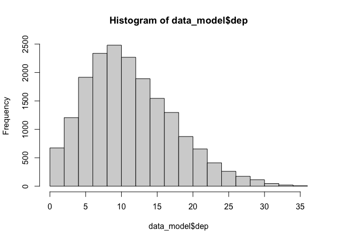

```r
#----------------------------------------------------------
# Variable de respuesta
#----------------------------------------------------------

# -----------------------------------------------
# distribución variable de respuesta
# -----------------------------------------------

hist(data_model$dep)
```

### Items de originales de la escala de Birleson (Depresión)

```
|PH_1  |Pienso que los días que vienen serán agradables
|PH_2  |Siento ganas de llorar
|PH_3  |Tengo ganas de arrancar o escapar
|PH_4  |Tengo dolores de estómago
|PH_5  |Quiero salir a jugar fuera de casa
|PH_6  |Duermo muy bien
|PH_7  |Tengo mucha energía
|PH_8  |Disfruto mis comidas
|PH_9  |Puedo arreglármelas solo, valerme por mi mismo
|PH_10 |Creo que no vale la pena vivir
|PH_11 |Me resultan bien las cosas que hago
|PH_12 |Disfruto lo que hago igual que antes
|PH_13 |Me gusta hablar con mi familia
|PH_14 |Tengo sueños horribles
|PH_15 |Me siento muy solo
|PH_16 |Me animo fácilmente, me entusiasmo con mucha facilidad
|PH_17 |Me siento tan triste que difícilmente lo soporto
|PH_18 |Me siento muy aburrido, lateado, choreado


# Notas:
# Categorias de respuesta
#
# 1 Nunca
# 2 A veces
# 3 Siempre
```

## Datos para realizar inferencias a la población

```r
#----------------------------------------------------------
# inferencia a la población
#----------------------------------------------------------

# -----------------------------------------------
# taylor series linearization
# -----------------------------------------------

library(srvyr)
poli_svy  <- data_model %>%
             remove_labels() %>%
             as_survey_design(
             strata = var_strat,
             ids = var_unit,
             weights = wgt_alu,
             nest = TRUE,
             check_strata = TRUE
             )

# Opción: corección a unidad primaria de muestreo que resulte
# única al estrato

library(survey)
options(survey.lonely.psu="adjust")
```

## Descriptivos por grupo

- Los descriptivos producidos sirven para realizar inferencias a la población de estudiantes, basados en diseño.

```r
#----------------------------------------------------------
# descriptivos
#----------------------------------------------------------

# -----------------------------------------------
# por tipo de escuela
# -----------------------------------------------

poli_svy %>%
group_by(adm_text) %>%
summarize(
mean_dep = survey_mean(dep, na.rm = TRUE, vartype = c('se','ci'))
) %>%
knitr::kable(., digits = 2)
```

| adm_text | mean_dep | mean_dep_se | mean_dep_low | mean_dep_upp |
| --- | --- | --- | --- | --- |
| municipal | 11.95 | 0.12 | 11.71 | 12.19 |
| particular | 10.12 | 0.23 | 9.66 | 10.58 |
| subvencionado | 11.84 | 0.08 | 11.68 | 12.01 |

```r
# -----------------------------------------------
# por tipo grupo etario
# -----------------------------------------------

poli_svy %>%
group_by(edad_text) %>%
summarize(
mean_dep = survey_mean(dep, na.rm = TRUE, vartype = c('se','ci'))
) %>%
knitr::kable(., digits = 2)
```

| edad_text | mean_dep | mean_dep_se | mean_dep_low | mean_dep_upp |
| --- | --- | --- | --- | --- |
| 12 a 13 | 11.24 | 0.12 | 11.01 | 11.47 |
| 14 a 15 | 11.89 | 0.10 | 11.70 | 12.08 |
| 16 o más | 11.85 | 0.11 | 11.64 | 12.07 |
|  | 12.64 | 0.47 | 11.71 | 13.57 |

## Modelos de Regresión

- Los resultados generados por los modelos de regresión empleando diseño, son estimados que permiten realizar inferencias hibridas, basadas en diseño y basadas en modelo de forma simultánea (ver Sterba, 2009).

```r
#----------------------------------------------------------
# model comparison
#----------------------------------------------------------

# -----------------------------------------------
# equation
# -----------------------------------------------

f01 <- as.formula(dep ~ + 1 + mun + pri)
f02 <- as.formula(dep ~ + 1 + ed1 + ed3)
f03 <- as.formula(dep ~ + 1 + sub + pri + ed1 + ed3)


# -----------------------------------------------
# regressions with clustered errors (TSL)
# -----------------------------------------------

m01 <- survey::svyglm(f01, design = poli_svy)
m02 <- survey::svyglm(f02, design = poli_svy)
m03 <- survey::svyglm(f03, design = poli_svy)

#--------------------------------------
# compare models
#--------------------------------------

texreg::screenreg(
    list(m01, m02, m03),
    star.symbol = "*",
    center = TRUE,
    doctype = FALSE,
    dcolumn = TRUE,
    booktabs = TRUE,
    single.row = FALSE
    )
```

```
##
## ========================================================
##              Model 1        Model 2        Model 3
## --------------------------------------------------------
## (Intercept)      11.84 ***      11.89 ***      12.09 ***
##                  (0.08)         (0.10)         (0.14)
## mun               0.11
##                  (0.15)
## pri              -1.72 ***                     -1.82 ***
##                  (0.25)                        (0.26)
## ed1                             -0.65 ***      -0.64 ***
##                                 (0.15)         (0.14)
## ed3                             -0.04          -0.05
##                                 (0.13)         (0.13)
## sub                                            -0.07
##                                                (0.15)
## --------------------------------------------------------
## Deviance     684017.80      678622.37      673927.78
## Dispersion       37.63          37.76          37.49
## Num. obs.     18180          17975          17975
## ========================================================
## *** p < 0.001; ** p < 0.01; * p < 0.05
```

```r
#--------------------------------------
# variables
#--------------------------------------

# dep = puntaje de depresion de Birlesson
#       min = 0, max = 36, media = 11.72

# mun = escuelas municipales (sí = 1, no = 0)

# sub = escuelas subvencionales (sí = 1, no = 0)

# pri = escuelas privadas (sí = 1, no = 0)

# ed1 = edad, 12 a 13 años (sí = 1, no = 0)

# ed2 = edad, 14 a 15 años (sí = 1, no = 0)

# ed3 = edad, 16 o más (sí = 1, no = 0)
```

## Tabla de resultados

```
========================================================
             Model 1        Model 2        Model 3
--------------------------------------------------------
(Intercept)      11.84 ***      11.89 ***      12.09 ***
                 (0.08)         (0.10)         (0.14)
mun               0.11
                 (0.15)
pri              -1.72 ***                     -1.82 ***
                 (0.25)                        (0.26)
ed1                             -0.65 ***      -0.64 ***
                                (0.15)         (0.14)
ed3                             -0.04          -0.05
                                (0.13)         (0.13)
sub                                            -0.07
                                               (0.15)
--------------------------------------------------------
Deviance     684017.80      678622.37      673927.78
Dispersion       37.63          37.76          37.49
Num. obs.     18180          17975          17975
========================================================
*** p < 0.001; ** p < 0.01; * p < 0.05
```

**Notas sobre los resultados**

- En el modelo 1 (Model 1):
  - En el modelo 1, solo se ingresan como covariables a las covariables que nos informan respecto a la administración de la escuela, en la que se encuentran los estudiantes.
  - Intercepto: es la media de puntajes de depresión, de las escuelas subvencionadas
  - Pendiente 1: es la diferencia de medias, entre los estudiantes en escuelas municipales, y el intercepto (media de puntajes de los estudiantes en escuelas subvencionadas)
  - Pendiente 2: es la diferencia de medias, entre los estudiantes en escuelas privadas, y el intercepto (media de puntajes de los estudiantes en escuelas subvencionadas)
- En el modelo 2 (Model 2):
  - Intercepto: es la media de puntajes de depresión de los estudiantes de 14 a 15 años.
  - Pendiente 1: es la diferencia de medias, de los estudiantes de 12 a 13 años, en contraste al intercepto.
  - Pendiente 2: es la diferencia de medias, de los estudiantes de 16 o más años, en contraste al intercepto.
- En el modelo 3 (Model 3):
  - Intercepto: es la media de puntajes esperados, para los estudiantes en escuelas municipales, de 14 a 15 años.
  - Pendiente 1: es la diferencia de medias, de los estudiantes en escuelas privadas, y el intercepto de modelo del modelo.
  - Pendiente 2: es la diferencia de medias, de los estudiantes de 12 a 13 años, en contraste al intercepto del modelo.
  - Pendiente 3: es la diferencia de medias, de los estudiantes de 16 o más años, en contraste al intercepto del modelo.
  - Pendiente 4: es la diferencia de medias, entre los estudiantes en escuelas subvencionadas, y el intercepto del modelo.

## Datos Perdidos

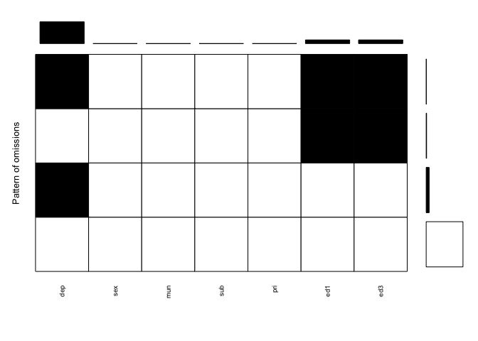

```r
#----------------------------------------------------------
# preparar datos
#----------------------------------------------------------

library(VIM)
data_model %>%
dplyr::select(dep, sex, mun, sub, pri, ed1, ed3) %>%
# dplyr::sample_n(1000) %>%
VIM::aggr(.,
  combine  = TRUE,
  cex.lab  = .8,
  cex.axis = .6,
  col      = c("white", "black"),
  ylabs    = "Pattern of omissions"
  )
```

## R2 con lavaan.survey

```r
#----------------------------------------------------------
# lavaan model
#----------------------------------------------------------

# -----------------------------------------------
# model
# -----------------------------------------------

model_04 <-
'
dep ~ sex + sub + pri + sex + ed1 + ed3
'

# -----------------------------------------------
# fit
# -----------------------------------------------

fit_04 <- lavaan::sem(model_04, data = data_model, mimic="Mplus", estimator = "MLR")

# -----------------------------------------------
# fit with svy
# -----------------------------------------------

svy_04 <- lavaan.survey::lavaan.survey(
                 lavaan.fit = fit_04,
                 survey.design = poli_svy)


# -----------------------------------------------
# results
# -----------------------------------------------

lavaan::summary(svy_04,standardized=TRUE, fit.measures=TRUE, rsquare=TRUE)
```

```
## lavaan 0.6-12 ended normally after 42 iterations
##
##   Estimator                                         ML
##   Optimization method                           NLMINB
##   Number of model parameters                         7
##
##   Number of observations                         19433
##
## Model Test User Model:
##                                               Standard      Robust
##   Test Statistic                                 0.000       0.000
##   Degrees of freedom                                 0           0
##
## Model Test Baseline Model:
##
##   Test statistic                              1962.835     837.907
##   Degrees of freedom                                 5           5
##   P-value                                        0.000       0.000
##   Scaling correction factor                                  2.343
##
## User Model versus Baseline Model:
##
##   Comparative Fit Index (CFI)                    1.000       1.000
##   Tucker-Lewis Index (TLI)                       1.000       1.000
##
##   Robust Comparative Fit Index (CFI)                         1.000
##   Robust Tucker-Lewis Index (TLI)                            1.000
##
## Loglikelihood and Information Criteria:
##
##   Loglikelihood user model (H0)             -61858.181  -61858.181
##   Loglikelihood unrestricted model (H1)     -61858.181  -61858.181
##
##   Akaike (AIC)                              123730.363  123730.363
##   Bayesian (BIC)                            123785.486  123785.486
##   Sample-size adjusted Bayesian (BIC)       123763.240  123763.240
##
## Root Mean Square Error of Approximation:
##
##   RMSEA                                          0.000       0.000
```

[output cut: 23 more lines]

```
##     pri              -1.750    0.283   -6.172    0.000   -1.750   -0.081
##     ed1              -0.776    0.147   -5.271    0.000   -0.776   -0.054
##     ed3               0.060    0.134    0.451    0.652    0.060    0.005
##
## Intercepts:
##                    Estimate  Std.Err  z-value  P(>|z|)   Std.lv  Std.all
##    .dep              10.234    0.136   75.204    0.000   10.234    1.667
##
## Variances:
##                    Estimate  Std.Err  z-value  P(>|z|)   Std.lv  Std.all
##    .dep              34.070    0.477   71.415    0.000   34.070    0.904
##
## R-Square:
##                    Estimate
##     dep               0.096
```

# Referencias

Sterba, S. K. (2009). Alternative Model-Based and Design-Based Frameworks for Inference From Samples to Populations: From Polarization to Integration. In Multivariate Behavioral Research (Vol. 44, Issue 6, pp. 711–740). https://doi.org/10.1080/00273170903333574